# Your First App, Jeff Leek Facts

## Creating your first app

- In this lecture, you'll create your first app
- We'll be creating a *custom skill* using Amazon's Alexa Voice Service and Lambda
- Make sure that you have an account on the Alexa Skills Developer Portal
- Since we'll be using the Lambda free tier, this won't cost anything for development

## Hello world

- The first step will be to do Amazon's recommended "Hello World" app
- This uses node.js, but don't worry if you don't know it, we're just going to be copy and pasting.
- Example developed by Diego Benitez
- The github repo for the example is at

https://github.com/alexa/skill-sample-nodejs-fact

- You can clone the repo, or just copy and paste code from there
- There's great directions there

## Sign into the Amazon developer portal

- I often forget the url, google searching for "Alexa Skills Developer Console" it's the first hit
- https://developer.amazon.com/home.html
- Make sure that you're signed in (upper right)
- Click on Alexa

## Click on "Alexa Skills Kit"

[figure not shown]

## Add a new skill

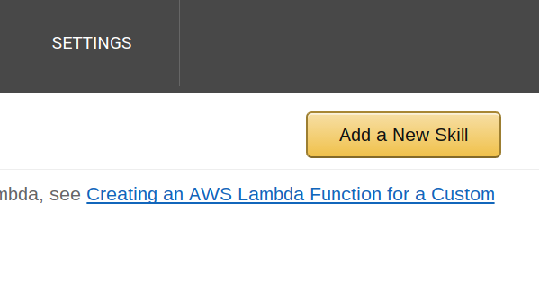

## Make sure "Custom Interaction Model" is checked

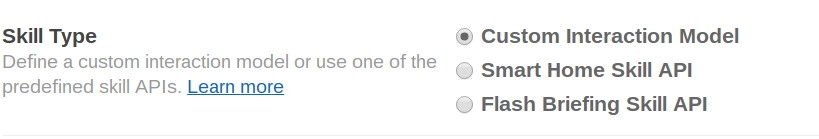

## The interaction model

- Amazon has launched a new interface called the "Skill Builder". Since this is still in beta, we'll do it using the existing interface. However, the Skill Builder is pretty cool, so give it a try on a next app.
- First we need to add some `intents`. From Amazon

*"An intent represents an action that fulfills a user’s spoken request. Intents can optionally have arguments called slots."*

- I think of intents as variable names for interactions with Alexa

## The intent schema from the repo

```
{
  "intents": [
    {
      "intent": "GetNewFactIntent"
    },
    {
      "intent": "AMAZON.HelpIntent"
    },
    {
      "intent": "AMAZON.StopIntent"
    },
    {
      "intent": "AMAZON.CancelIntent"
    }
  ]
}
```

## Sample utterances

- These are the things that people will say to invoke the skill
- Try to include as many phrases as you can
- Have to match your intent definitions (Amazon will give an error if not)

```
GetNewFactIntent a fact
GetNewFactIntent a Jeff fact
GetNewFactIntent tell me a Jeff fact
GetNewFactIntent tell me a Jeff fact
GetNewFactIntent give me a fact
GetNewFactIntent give me a Jeff fact
GetNewFactIntent tell me Jeff Leek fact
```

Click `Save` and then `Next`

## Check `AWS Lambda ARN (Amazon Resource Name)`

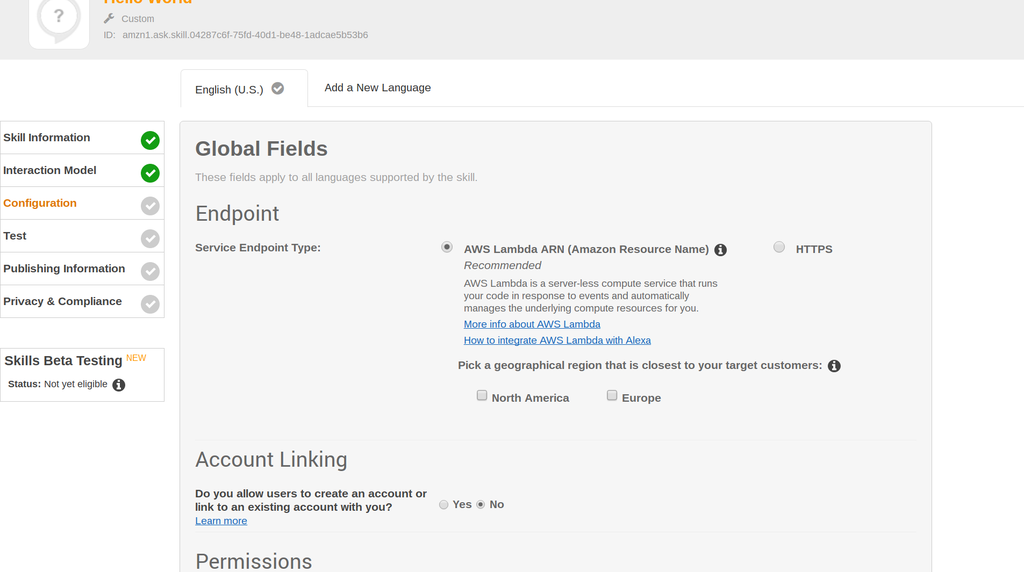

You also have to pick a geographical region, my was `North America` and then filled in with data from your lambda app, so we'll come back to this

## Sign in to Amazon Web Services (AWS)

- Get an AWS account and sign in to the management console at https://aws.amazon.com/
- Make sure that you're using `US East (N. Virgina)` in the upper right dialog box

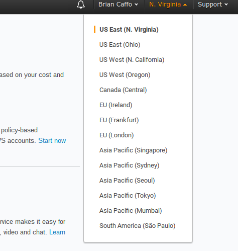

## Check on the `Lambda` link in `Services` (upper left)

[figure not shown]

## Click on `Create Lambda Function`

[figure not shown]

## Select `Blank Function`

The follow these instructions to get Alexa Skills Kit to trigger the function

[figure not shown]

## It should look like this

[figure not shown]

## Scroll down

- There's more. Keep your environment variables blank
- Keep your `Handler` as `index.handler`
- `Role*` as `Create custom role`

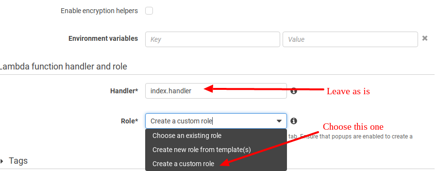

## Use the auto-populated values on this page and click `Allow`

Leave `Tags` and `Advanced` as is and click next

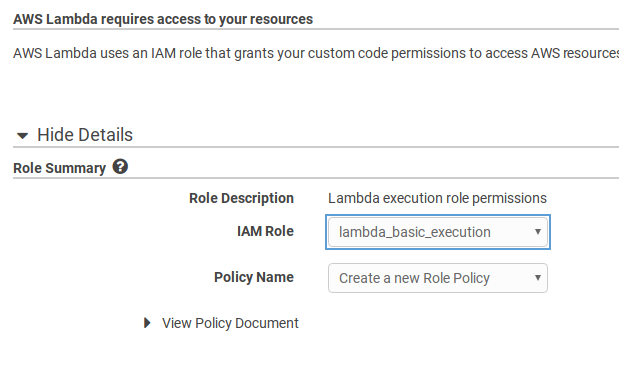

## Click `Create Function`

[figure not shown]

## Get your `ARN` number (upper right)

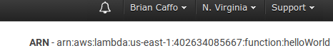

## Paste it into your `Endpoint`

Not in AWS, in the Alexa Skills Kit Developer Console

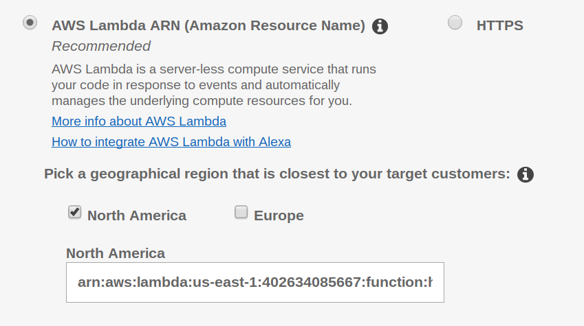

## Now you can test your skill

[figure not shown]

## You can also test your skill on lambda to debug there

- Copy your Lambda request from your Alexa Developer Console test page for your app
- Paste it into your `Configure test event`
- Click on `Test`

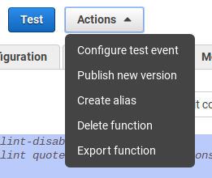

## See the result and log files below on the same page

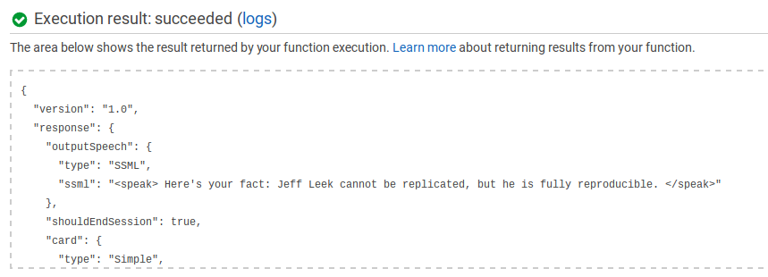